# act_report

### Virtual Analysis Report

The master_df was wrangled, assessed and analysed. Th report on the analysis done and its foundings can be found in this report.

#### What stage of dog was more prominent

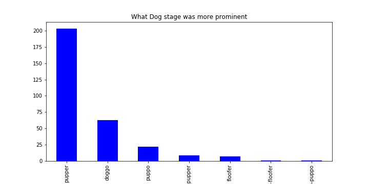

```python
from IPython.display import Image
Image(filename='dogstageplot.png')
```

During this analysis the none values were excluded as this will skew our report negatively and are not needed for the results we are trying to achieve

From the plot above, pupper was the most common stage among dogs displayed on WeRateDogs twitter page.

#### Trend of followers of WeRateDogs twitter account across the period the data was collected

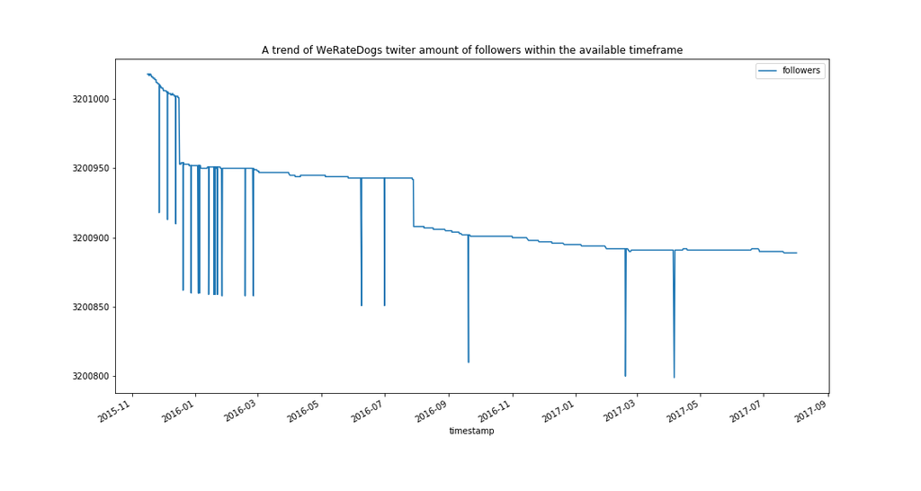

```python
from IPython.display import Image
Image(filename='timetrendplot.png')
```

A decline in the total amount of followers was noticed across the years. This maybe one variable they might want to look at as an increase in followers will mean a wider audience reach for WeRateDogs.

#### Dog names that are most prominent in WeRateDogs twitter account

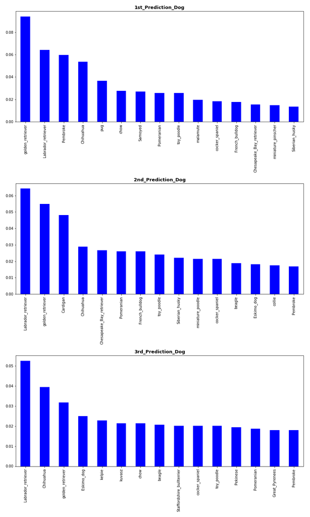

```python
from IPython.display import Image
Image(filename='breedplot.png')
```

We can deduce from the above set of plots that golden_retriever and labrador_retriever are very good looking dog breed as they are prominent in the amount of appearnces in the top 3 dogs in each chart.

#### Heat map showing the relationships between retweets, favourites, followers

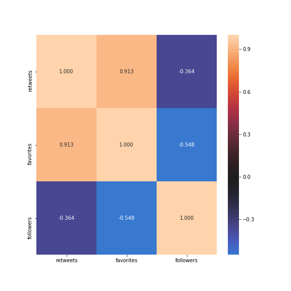

```python
from IPython.display import Image
Image(filename='heatmapplot.png')
```

From the above heatmap, we can deduce;

favorites and retweets have a strong positive correation, therefore the more likes we get, the more retweets of that post we are likely to get.

followers is negatively correlated to both favourites and retweets, although followers has a weak negative correlation with retweets compared to favourites